# final project

2023-05-17

# Construct multiple models to forecast inflation rate according to CPI and PPI

## Data pre-processing

Import data

```r
url <- "https://github.com/zhentaoshi/Econ5821/raw/main/data_example/dataset_inf.Rdata"
# 设置本地文件名
filename <- "dataset_inf.Rdata"

# 下载文件
download.file(url, destfile = filename, mode = "wb")

# 读取数据文件
load(filename)
```

Remove variables with high same-value rates

```r
# Count the number of occurrences of the value of each column variable
value_counts <- lapply(X, table)
# Calculate the parity rate of each column variable
homogeneity <- sapply(value_counts, function(x) max(x) / sum(x))
# Gets the variable with a high rate of homogeneity
high_homogeneity_vars <- names(homogeneity[homogeneity > 0.95])
# Print variables with high rates of the same value
cat("Variables with high homogeneity (> 0.95):\n")
```

```
## Variables with high homogeneity (> 0.95):
```

```r
for (var in high_homogeneity_vars) {
  cat(var, "\n")
}
```

```
## 人民银行对金融机构贷款利率再贴现利率月_一阶差分
## 人民银行对金融机构贷款利率20天以内月_一阶差分
## 人民银行对金融机构贷款利率3个月以内月_一阶差分
## 人民银行对金融机构贷款利率6个月以内月_一阶差分
## 人民银行对金融机构贷款利率1年月_一阶差分
## 活期存款利率月_一阶差分
```

```r
# Determine a threshold for the same rate (e.g., variables with a rate above 0.95 will be eliminated)
threshold <- 0.95
# Remove variables according to the threshold of the same rate
X1 <- X[, homogeneity < threshold]
```

Generate the year-on-year growth rates of ppi

```r
# Calculated year-on-year growth rate of ppi（inflation rate）
ppi_yoy <- ((ppi[13:168, 2] / ppi[1:156, 2]) - 1)*100

ppi_yoy_df <- data.frame(month = ppi$month[13:168], PPI_YoY = ppi_yoy)
X1 <- X1[13:168, ]

#Convert the data into time series data
# Calculate the year and month
years <- floor((X1$month - 1) / 12) + 2000
months <- (X1$month - 1) %% 12 + 1

# The xts function is used to convert the data into time series data
library(zoo)
library(xts)
dates <- as.Date(paste0(years, "-", months, "-01"))
X1 <- xts(X1[, -1], order.by = dates)
#head(X1)

dates <- as.Date(paste0(years, "-", months, "-01"))
ppi_yoy_df <- xts(ppi_yoy_df [, -1], order.by = dates)
#head(ppi_yoy_df )
```

```r
# Install and load the tseries package
library(tseries)
#  A data box for storing stationary results
results <- data.frame(Variable = character(0), Stability = character(0), stringsAsFactors = FALSE)

# Each variable is traversed for a unit root check
for (var in names(X1)) {
  result <- adf.test(X1[,var], alternative = "stationary")
  #  Extract the p-value of the unit root test result
  p_value <- result$p.value
  # Determine whether the variable is stationary
  is_stable <- p_value < 0.05
  # Add the result to the data box
  results <- rbind(results, data.frame(Variable = var, Stability = ifelse(is_stable, "Stable", "Not Stable"), stringsAsFactors = FALSE))
}

# Print stationary results
print(results)
```

```
##                                                   Variable  Stability
## 1                      规模以上工业增加值_当期同比实际增速     Stable
## 2                                      发电量_当期同比增速     Stable
## 3                                    原煤产量_当期同比增速 Not Stable
## 4                                    焦炭产量_当期同比增速     Stable
## 5                                    粗钢产量_当期同比增速     Stable
## 6                                    钢材产量_当期同比增速     Stable
## 7                                    原油产量_当期同比增速 Not Stable
## 8                                    乙烯产量_当期同比增速 Not Stable
## 9                            十种有色金属产量_当期同比增速     Stable
## 10                                   汽车产量_当期同比增速     Stable
## 11                               工业锅炉产量_当期同比增速 Not Stable
## 12                             金属集装箱产量_当期同比增速 Not Stable
## 13             固定资产投资完成额不含农户_当期实际同比增速 Not Stable
## 14    固定资产投资完成额不含农户_第一产业_当期实际同比增速 Not Stable
```

[output cut: 131 more lines]

```r
# Extract the column names of stable variables from the stability results
stable_vars <- results$Variable[results$Stability == "Stable"]

# Extract stable variables from the original data
X_stable <- subset(X1, select = c(stable_vars))
```

```r
#Detection of multicollinearity Severe multicollinearity was found in k>1000
kappa(X_stable)
```

```
## [1] 5.575182e+19
```

```r
# custom normalization function
normalize <- function(x) {
  return((x - min(x)) / (max(x) - min(x)))
}
# apply normalization to entire data frame
data_standard <- as.data.frame(apply(X_stable,2,normalize))
```

```r
#combine PPI_yoy and independent variables
data <- cbind(data_standard, ppi_yoy_df)
```

1. Divide the training set and test set

```r
#The independent variable was merged with the PPI data
data <- cbind(data_standard, ppi_yoy_df)
#dim(data)
# Determine partition point
n_train <- round(nrow(data) * 0.8)
# Divide the training set and test set
train_ <- data[1:n_train,]
test_ <- data[(n_train + 1):nrow(data),]
# Convert the data into a matrix
x1 <- as.matrix(train_[, 1:(ncol(train_) - 1)])
x2 <- as.matrix(test_[, 1:(ncol(test_) - 1)])
y1 <- train_[, ncol(train_)]
y2 <- test_[, ncol(test_)]
# Transform data structure
x1 <- array(x1, dim = c(dim(x1)[1], dim(x1)[2], 1))
x2 <- array(x2, dim = c(dim(x2)[1], dim(x2)[2], 1))
```

RNN (Recurrent Neural Network) and LSTM (Recurrent short-term memory network) both belong to a class of recurrent neural network models used to process sequential data. The main differences are as follows: (1)Parameter structure: LSTM introduces the structure of gated unit and has more parameters than traditional RNN to control the flow and forgetting of information. (2)Long-term dependence: LSTM can better capture long-term dependence through the design of gated unit. Traditional RNN is prone to gradient disappearance or gradient explosion when processing long sequences, which makes it difficult to capture long-term dependence. (3)Computational efficiency: Compared with traditional RNN, LSTM has higher computational complexity because it introduces more parameters and computation steps. (4)Application scenario: Traditional RNN is suitable for processing short sequence data or scenarios requiring fast calculation. LSTMS perform better on tasks that are more important for dealing with long sequences and long-term dependencies. LSTM is an improved version of RNN, which solves the problem of traditional RNN when dealing with long sequences by introducing the design of gated unit. LSTM has advantages in tasks dealing with long-term dependencies and is widely used in modeling and forecasting for a variety of sequence data.

```r
#install.packages("keras")
#install.packages("tensorflow")
#install.packages("tidyverse")
#install.packages("magrittr")
library(keras)
library(tensorflow)
library(tidyverse)
library(magrittr)
```

```r
# Build a model
model <- keras_model_sequential() %>%
  layer_lstm(units = 64, input_shape = c(ncol(x1), 1)) %>%
  layer_dropout(0.2) %>%
  layer_dense(units = 1)
# Compilation model
model %>% compile(
  loss = "mean_squared_error",
  optimizer = optimizer_adam(),
  metrics = c("mean_absolute_error")
)
# Training model
history <- model %>% fit(
  x1, y1,
  epochs = 100,
  batch_size = 32,
  validation_data = list(x2, y2),
  verbose = 1
)
```

- Show the forecast results

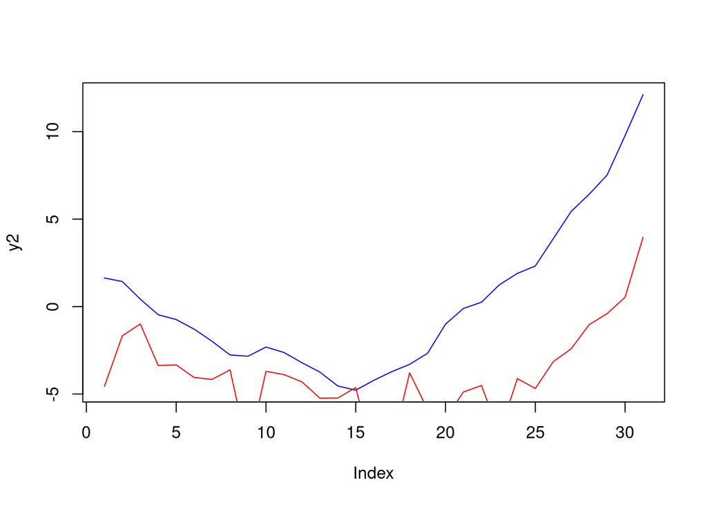

```r
# Anticipate and visualize the results
y_pred <- model %>% predict(x2)
plot(y2, type = "l", col = "blue")
lines(y_pred, col = "red")
```

```r
# Calculate MSE and R-squared
#install.packages("caret")
#library(caret)
mse_RNN <- mean((y_pred - y2)^2)
r_squared_RNN <- cor(y_pred, y2)^2
mse_RNN
```

```
## [1] 25.09027
```

```r
r_squared_RNN
```

```
##           [,1]
## [1,] 0.6015279
```

3. LSTM
- Build the model and train the data

```r
# Define the LSTM model
model <- keras_model_sequential() %>%
  layer_lstm(units = 64, return_sequences = TRUE, input_shape = c(dim(x1)[2], dim(x1)[3])) %>%
  layer_dropout(rate = 0.2) %>%
  layer_lstm(units = 32, return_sequences = FALSE) %>%
  layer_dropout(rate = 0.2) %>%
  layer_dense(units = 1)
#summary(model)
# Compilation model
model %>% compile(
  loss = "mse",
  optimizer = optimizer_adam(lr = 0.001),
  metrics = list("mse")
)
# Training model
history <- model %>% fit(
  x1, y1,
  batch_size = 32,
  epochs = 50,
  validation_data = list(x2, y2),
  verbose = 2
)
```

- Show the forecast results

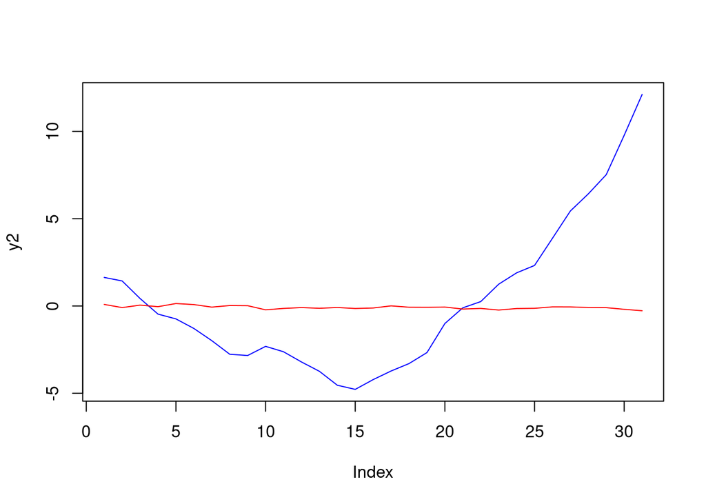

```r
# Anticipate and visualize the results
y_pred <- model %>% predict(x2)
plot(y2, type = "l", col = "blue")
lines(y_pred, col = "red")
```

```r
# Calculate MSE and R-squared
mse_LSTM <- mean((y_pred - y2)^2)
r_squared_LSTM <- cor(y_pred, y2)^2
mse_LSTM
```

```
## [1] 18.13141
```

```r
r_squared_LSTM
```

```
##           [,1]
## [1,] 0.0864424
```

The two graphs show the predicted values of the two models which is red compared to the true values which is blue. By observing the MSE and R-square of the two models, we can find that the two prediction results are both not ideal, so we do not recommend using these two models to predict the inflation rate.

In our dataset, there are many kinds of independent variables and high multicollinearity, so ordinary regression predictions will be less effective. So we consider using machine learning methods that can reduce dimensionality – the lasso regression method, the Ridge regression, the random forest and combined models.

4.LASSO:LASSO is a regularization method for linear regression. It constrains the size of regression coefficients by adding an L1 penalty term, and can set some regression coefficients to zero during the penalty process, thereby achieving feature selection.

```r
# Determine partition point
n_train <- round(nrow(data) * 0.8)

# Divide the training set and test set
train_ <- data[1:n_train,]
test_ <- data[(n_train + 1):nrow(data),]

# Convert the data into a matrix
x1 <- as.matrix(train_[, 1:103])
x2 <- as.matrix(test_[, 1:103])
y1 <- train_[, 104]
y2 <- test_[, 104]


library(Matrix)
#install.packages("glmnet")
library(glmnet)
#lasso
#10-fold cross-validation to determine the best lamda
cv.fit<-cv.glmnet(x1,y1,alpha=1,nfolds=10,family = "gaussian",type.measure="mse")
cv.fit$lambda.1se
```

```
## [1] 0.1387129
```

```r
coef(cv.fit,s=cv.fit$lambda.1se)
```

```
## 104 x 1 sparse Matrix of class "dgCMatrix"
##                                                                 s1
## (Intercept)                                             -8.7700050
## 规模以上工业增加值_当期同比实际增速                      .
## 发电量_当期同比增速                                      .
## 焦炭产量_当期同比增速                                   -1.5954798
## 粗钢产量_当期同比增速                                    .
## 钢材产量_当期同比增速                                    .
## 十种有色金属产量_当期同比增速                            .
## 汽车产量_当期同比增速                                    4.5580938
## 固定资产投资完成额不含农户_第二产业_当期实际同比增速    -2.5225236
## 固定资产投资完成额不含农户_第三产业_当期实际同比增速     .
## 房地产开发投资_当期实际同比增速                          .
## 房地产开发企业新增固定资产_当期实际同比增速              .
## 房地产开发投资_住宅_当期实际同比增速                     .
## 房地产开发企业房屋施工面积_当期同比增速                  0.7683181
## 房地产开发企业房屋竣工面积_当期同比增速                  .
## 消费者预期指数_当期_一阶差分                             .
## 消费者满意指数_当期_一阶差分                             .
## 消费者信心指数_当期_一阶差分                             .
## 进出口总额美元_当期实际同比增速                          7.0764769
## 进口额美元_当期实际同比增速                            -21.0206441
## 出口商品价格指数上年同期100_当期                        -4.1118741
## 进口商品价格指数上年同期100_当期                         .
## 出口商品数量增长指数上年同月100_当期                     .
## 进口商品数量增长指数上年同月100_当期                    11.5238201
## 贸易条件_一阶差分                                        0.4419292
## 出口占进口比例_一阶差分                                 -1.0930692
## 期货成交量_郑州商品交易所_当期同比增速                   .
## 期货成交额_郑州商品交易所_当期同比增速                   1.9455732
## 期货平均价格_郑州商品交易所_一阶差分                     .
## 期货平均价格_大连商品交易所_一阶差分                     .
## 期货平均价格_上海商品交易所_一阶差分                     .
## 外汇储备_期末同比增速                                   -0.8586928
## 汇率指数收益率                                          -1.0044147
## l即期汇率欧元兑人民币_一阶差分                           .
## l日元兑人民币平均汇率_当期_一阶差分                      .
## l即期汇率英镑兑人民币_一阶差分                           0.5144834
## 一般公共预算支出_当期实际同比增速                       -0.4251495
## 一般公共预算收入_当期实际同比增速                       -1.9699300
```

[output cut: 51 more lines]

```
## 中债银行间债券总指数收益率                               .
## 中债国债总指数收益率                                     .
## 中债金融债券总指数收益率                                 .
## 上证基金指数收益率                                       .
## 美国工业生产指数全部工业非季调_当期同比增速              3.7514462
## 美国CPI当月同比                                          .
## 美国标准普尔500指数收盘价收益率                          .
## 美国纳斯达克综合指数收盘价收益率                         .
## 美国道琼斯工业平均指数收盘价收益率                       .
## CRB现货指数食品收益率                                    .
## CRB现货指数家畜收益率                                    .
## CRB现货指数金属收益率                                    .
## CRB现货指数工业原料收益率                                .
## CRB现货指数纺织品收益率                                  .
## 波罗的海干散货指数BDI收益率                              .
```

```r
lasso.pred=predict(cv.fit,newx=x2, s=cv.fit$lambda.1se)
mse_lasso<-mean((lasso.pred-y2)^2)
mse_lasso
```

```
## [1] 3.538044
```

```r
r_squared_Lasso<- cor(lasso.pred, y2)^2
r_squared_Lasso
```

```
##         [,1]
## s1 0.9514836
```

5.Ridge: It uses L2 regularization, which adds a penalty term based on the square of the coefficients to the loss function. This effectively shrinks all regression coefficients towards zero, but they will not be exactly zero.

```r
# Determine partition point
n_train <- round(nrow(data) * 0.8)

# Divide the training set and test set
train_ <- data[1:n_train,]
test_ <- data[(n_train + 1):nrow(data),]

# Convert the data into a matrix
x1 <- as.matrix(train_[, 1:103])
x2 <- as.matrix(test_[, 1:103])
y1 <- train_[, 104]
y2 <- test_[, 104]
library(MASS)
library(glmnet)

set.seed(123)

fit <- glmnet(x1, y1, alpha=0)

# 10-fold cross-validation to determine the best lamda度
cv.fit <- cv.glmnet(x1, y1, alpha=0, nfolds=10)
best.lambda <- cv.fit$lambda.min
ridge <- glmnet(x1, y1, alpha=0, lambda=best.lambda)


ridge.y0 <- predict(ridge, newx = x2,s=10)
#calculate MSE
mse_ridge<-mean((y2 - ridge.y0)^2)
mse_ridge
```

```
## [1] 5.158927
```

```r
#R squared
r_squared_ridge<- cor(ridge.y0,y2)^2
r_squared_ridge
```

```
##         [,1]
## s1 0.9531145
```

6.Random Forest

```r
# Determine partition point
n_train <- round(nrow(data) * 0.8)

# Divide the training set and test set
train_ <- data[1:n_train,]
test_ <- data[(n_train + 1):nrow(data),]

# Convert the data into a matrix
x1 <- as.matrix(train_[, 1:103])
x2 <- as.matrix(test_[, 1:103])
y1 <- train_[, 104]
y2 <- test_[, 104]

library(randomForest)
set.seed(12345)
(rFM<-randomForest(y1~.,data=train_,importance=TRUE,proximity=TRUE))
```

```
##
## Call:
##  randomForest(formula = y1 ~ ., data = train_, importance = TRUE,      proximity = TRUE)
##                Type of random forest: regression
##                      Number of trees: 500
## No. of variables tried at each split: 34
##
##           Mean of squared residuals: 1.345349
##                     % Var explained: 96.73
```

```r
Fit<-predict(rFM,test_)
mse_FM<-mean((Fit-y2)^2)
mse_FM
```

```
## [1] 20.35408
```

```r
r_squared_FM <- cor(Fit, y2)^2
r_squared_FM
```

```
## [1] 0.9236907
```

```r
#Importance measure
head(treesize(rFM))
```

```
## [1] 40 37 41 39 41 40
```

```r
head(getTree(rfobj=rFM,k=1,labelVar=TRUE))
```

```
##   left daughter right daughter                                   split var
## 1             2              3      工业生产者出厂价格指数上年同期100_当期
## 2             4              5 工业生产者出厂价格指数上年同期100_食品_当期
## 3             6              7            企业商品价格指数上年同期100_当期
## 4             8              9                       钢材产量_当期同比增速
## 5             0              0                                        <NA>
## 6            10             11      期货成交额_郑州商品交易所_当期同比增速
##   split point status  prediction
## 1  0.27950820     -3   0.1054192
## 2  0.09740260     -3 -12.8585487
## 3  0.72131148     -3   1.7405143
## 4  0.29579861     -3 -13.9434648
## 5  0.00000000     -1 -10.1462583
## 6  0.02249819     -3  -1.6094613
```

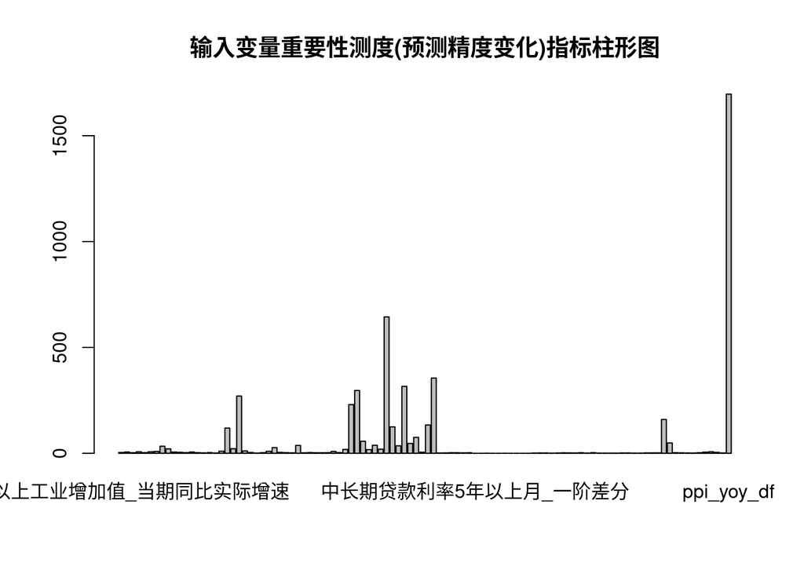

```r
barplot(rFM$importance[,2],main="输入变量重要性测度(预测精度变化)指标柱形图")
```

```r
importance(rFM,type=1)
```

```
##                                                             %IncMSE
## 规模以上工业增加值_当期同比实际增速                     1.626102740
## 发电量_当期同比增速                                     2.467881353
## 焦炭产量_当期同比增速                                   0.834107464
## 粗钢产量_当期同比增速                                   1.541831709
## 钢材产量_当期同比增速                                   0.947121419
## 十种有色金属产量_当期同比增速                           2.687740468
## 汽车产量_当期同比增速                                   2.481677751
## 固定资产投资完成额不含农户_第二产业_当期实际同比增速    6.068667080
## 固定资产投资完成额不含农户_第三产业_当期实际同比增速    7.040537346
## 房地产开发投资_当期实际同比增速                         1.488321332
## 房地产开发企业新增固定资产_当期实际同比增速             0.663447189
## 房地产开发投资_住宅_当期实际同比增速                    2.043673602
## 房地产开发企业房屋施工面积_当期同比增速                 2.465593742
## 房地产开发企业房屋竣工面积_当期同比增速                 1.815247075
## 消费者预期指数_当期_一阶差分                           -0.807669710
## 消费者满意指数_当期_一阶差分                            0.364728197
## 消费者信心指数_当期_一阶差分                            0.969652082
## 进出口总额美元_当期实际同比增速                         1.898359775
## 进口额美元_当期实际同比增速                             8.026894797
## 出口商品价格指数上年同期100_当期                        4.759139063
## 进口商品价格指数上年同期100_当期                        8.694667691
## 出口商品数量增长指数上年同月100_当期                   -1.131103600
## 进口商品数量增长指数上年同月100_当期                   -1.008002718
## 贸易条件_一阶差分                                       1.176873801
## 出口占进口比例_一阶差分                                 2.106238515
## 期货成交量_郑州商品交易所_当期同比增速                  3.096660175
## 期货成交额_郑州商品交易所_当期同比增速                  2.962332858
## 期货平均价格_郑州商品交易所_一阶差分                    1.049765794
## 期货平均价格_大连商品交易所_一阶差分                   -1.827005012
## 期货平均价格_上海商品交易所_一阶差分                   -0.782583485
## 外汇储备_期末同比增速                                   4.806039725
## 汇率指数收益率                                         -1.427630309
## l即期汇率欧元兑人民币_一阶差分                         -0.095638657
## l日元兑人民币平均汇率_当期_一阶差分                     0.697977058
## l即期汇率英镑兑人民币_一阶差分                         -0.250686756
## 一般公共预算支出_当期实际同比增速                      -0.453794600
## 一般公共预算收入_当期实际同比增速                       2.520099587
## 财政收支比例                                            1.605110555
## 居民消费价格指数上年同期100_当期                        4.520911990
```

[output cut: 50 more lines]

```
## 中债国债总指数收益率                                    0.592184740
## 中债金融债券总指数收益率                                0.262358335
## 上证基金指数收益率                                     -0.591446516
## 美国工业生产指数全部工业非季调_当期同比增速             8.596364009
## 美国CPI当月同比                                         5.436829589
## 美国标准普尔500指数收盘价收益率                         0.093066415
## 美国纳斯达克综合指数收盘价收益率                       -0.017238014
## 美国道琼斯工业平均指数收盘价收益率                      0.273365389
## CRB现货指数食品收益率                                  -0.642913626
## CRB现货指数家畜收益率                                  -0.854865352
## CRB现货指数金属收益率                                   1.822703331
## CRB现货指数工业原料收益率                               1.816793796
## CRB现货指数纺织品收益率                                 0.799915877
## 波罗的海干散货指数BDI收益率                            -1.066058047
## ppi_yoy_df                                             28.120126878
```

```r
mse_FM
```

```
## [1] 20.35408
```

```r
r_squared_FM
```

```
## [1] 0.9236907
```

%IncMSE refers to the percentage increase in the sum of squared errors of the model compared to the original model after the value of a variable is randomly shuffled, that is, the importance of a variable is assessed by comparing the degree of impact of a variable on the model’s predictions. The larger the IncMSE, the greater the contribution of the variable to the model prediction and the greater the importance of the variable.

```r
# Calculate the importance of all variables in a random forest
rf_importance <- importance(rFM, type = 1)
imp_matrix <- as.matrix(rf_importance)
# Extract the variable name of %IncMSE greater than 0
selected_vars <- rownames(imp_matrix)[imp_matrix[, 1] > 1]
print(selected_vars)
```

```
##  [1] "规模以上工业增加值_当期同比实际增速"
##  [2] "发电量_当期同比增速"
##  [3] "粗钢产量_当期同比增速"
##  [4] "十种有色金属产量_当期同比增速"
##  [5] "汽车产量_当期同比增速"
##  [6] "固定资产投资完成额不含农户_第二产业_当期实际同比增速"
##  [7] "固定资产投资完成额不含农户_第三产业_当期实际同比增速"
##  [8] "房地产开发投资_当期实际同比增速"
##  [9] "房地产开发投资_住宅_当期实际同比增速"
## [10] "房地产开发企业房屋施工面积_当期同比增速"
## [11] "房地产开发企业房屋竣工面积_当期同比增速"
## [12] "进出口总额美元_当期实际同比增速"
## [13] "进口额美元_当期实际同比增速"
## [14] "出口商品价格指数上年同期100_当期"
## [15] "进口商品价格指数上年同期100_当期"
```

[output cut: 37 more lines]

7.Random Forest+Ridge: Use variables selected by random forests in ridge regression

```r
# Extract random forest important variables from the original normalized data
data_fm <- subset(data, select = c(selected_vars))

n_train2 <- round(nrow(data_fm) * 0.8)


train_ <- data_fm[1:n_train2,]
test_ <- data_fm[(n_train2 + 1):nrow(data_fm),]

x1 <- as.matrix(train_[, 1:51])
x2 <- as.matrix(test_[, 1:51])
y1 <- train_[, 52]
y2 <- test_[, 52]
###Ridge again
library(MASS)
library(glmnet)

set.seed(123)

fit <- glmnet(x1, y1, alpha=0)
cv.fit <- cv.glmnet(x1, y1, alpha=0, nfolds=10)
best.lambda <- cv.fit$lambda.min

ridge <- glmnet(x1, y1, alpha=0, lambda=best.lambda)


ridge.y0 <- predict(ridge, newx = x2,s=10)
#calculate MSE
mse_RM_Ridge<-mean((y2 - ridge.y0)^2)
mse_RM_Ridge
```

```
## [1] 7.387036
```

```r
#R squared
r_squared_RM_Ridge<- cor(ridge.y0,y2)^2
r_squared_RM_Ridge
```

```
##         [,1]
## s1 0.9518771
```

8.Random Forest+LASSO:Use variables selected by random forests in Lasso regression

```r
library(glmnet)
data_fm <- subset(data, select = c(selected_vars))

n_train2 <- round(nrow(data_fm) * 0.8)

train_ <- data_fm[1:n_train2,]
test_ <- data_fm[(n_train2 + 1):nrow(data_fm),]


x1 <- as.matrix(train_[, 1:51])
x2 <- as.matrix(test_[, 1:51])
y1 <- train_[, 52]
y2 <- test_[, 52]

cv.fit<-cv.glmnet(x1,y1,alpha=1,nfolds=10,family = "gaussian",type.measure="mse")
cv.fit$lambda.1se
```

```
## [1] 0.0956094
```

```r
coef(cv.fit,s=cv.fit$lambda.1se)
```

```
## 52 x 1 sparse Matrix of class "dgCMatrix"
##                                                                 s1
## (Intercept)                                             -7.8291201
## 规模以上工业增加值_当期同比实际增速                     -0.5500840
## 发电量_当期同比增速                                      3.3475803
## 粗钢产量_当期同比增速                                   -2.2424147
## 十种有色金属产量_当期同比增速                            .
## 汽车产量_当期同比增速                                    5.9560933
## 固定资产投资完成额不含农户_第二产业_当期实际同比增速    -1.6770670
## 固定资产投资完成额不含农户_第三产业_当期实际同比增速     .
## 房地产开发投资_当期实际同比增速                          .
## 房地产开发投资_住宅_当期实际同比增速                     .
## 房地产开发企业房屋施工面积_当期同比增速                  1.2684122
## 房地产开发企业房屋竣工面积_当期同比增速                 -0.3592669
## 进出口总额美元_当期实际同比增速                         11.3750633
## 进口额美元_当期实际同比增速                            -19.4837560
## 出口商品价格指数上年同期100_当期                        -7.6058231
## 进口商品价格指数上年同期100_当期                         1.4168854
## 贸易条件_一阶差分                                        2.1294838
## 出口占进口比例_一阶差分                                 -2.2526093
## 期货成交量_郑州商品交易所_当期同比增速                   .
## 期货成交额_郑州商品交易所_当期同比增速                   1.7145127
## 期货平均价格_郑州商品交易所_一阶差分                     .
## 外汇储备_期末同比增速                                   -1.8362013
## 一般公共预算收入_当期实际同比增速                       -1.6570231
## 财政收支比例                                             .
## 居民消费价格指数上年同期100_当期                         1.3769208
## 居民消费价格指数上年同期100_居住_当期                    1.8042434
## 工业生产者出厂价格指数上年同期100_当期                   1.7625623
## 工业生产者出厂价格指数上年同期100_采掘品_当期            5.0264938
## 工业生产者出厂价格指数上年同期100_生活资料_当期          .
## 工业生产者出厂价格指数上年同期100_食品_当期              .
## 工业生产者出厂价格指数上年同期100_一般日用品_当期        .
## 企业商品价格指数上年同期100_当期                         .
## 企业商品价格指数上年同期100_矿产品_当期                  .
## 企业商品价格指数上年同期100_煤油电_当期                  .
## 工业生产者购进价格指数上年同期100_当期                   .
## 工业生产者购进价格指数上年同期100_燃料动力类_当期        .
## 工业生产者购进价格指数上年同期100_黑色金属材料类_当期    9.2677198
## 工业生产者购进价格指数上年同期100_木材及纸浆类_当期      .
## 工业生产者购进价格指数上年同期100_其它工业原材料及半成   .
## 工业生产者购进价格指数上年同期100_农副产品类_当期        4.9155697
## 银行间同业拆借加权平均利率_1个月_当期_一阶差分           .
## 短期贷款利率6个月至1年含月_一阶差分                      .
## 定期存款利率3个月月_一阶差分                             .
## 定期存款利率6个月月_一阶差分                             .
## 定期存款利率3年整存整取月_一阶差分                       .
## 中债总指数收益率                                         .
## 中债浮动利率债券指数收益率                               .
## 中债中短期债券指数收益率                                 .
## 美国工业生产指数全部工业非季调_当期同比增速              4.7074500
## 美国CPI当月同比                                         -1.7536676
## CRB现货指数金属收益率                                    .
## CRB现货指数工业原料收益率                                0.7634532
```

```r
lasso.pred=predict(cv.fit,newx=x2, s=cv.fit$lambda.1se)
mse_RM_Lasso<-mean((lasso.pred-y2)^2)
mse_RM_Lasso
```

```
## [1] 5.153064
```

```r
r_squared_RM_Lasso<- cor(lasso.pred, y2)^2
r_squared_RM_Lasso
```

```
##         [,1]
## s1 0.9146231
```

```r
#Compare the results of the above models on the PPI inflation rate together
models <- c("RNN","LSTM","Lasso", "Ridge", "RF", "RF+Ridge", "RF+Lasso")
Rsquare <- c(r_squared_RNN, r_squared_LSTM, r_squared_Lasso, r_squared_ridge, r_squared_FM, r_squared_RM_Ridge, r_squared_RM_Lasso)
MSE <- c(mse_RNN, mse_LSTM,mse_lasso, mse_ridge, mse_FM, mse_RM_Ridge, mse_RM_Lasso)

table <- data.frame(Model = models, `R squared` = Rsquare, `MSE` = MSE)

print(table)
```

```
##      Model R.squared       MSE
## 1      RNN 0.6015279 25.090269
## 2     LSTM 0.0864424 18.131410
## 3    Lasso 0.9514836  3.538044
## 4    Ridge 0.9531145  5.158927
## 5       RF 0.9236907 20.354084
## 6 RF+Ridge 0.9518771  7.387036
## 7 RF+Lasso 0.9146231  5.153064
```